# Tarea_4_27660553

## Descarga de Datos

|  | entity_name | entity_id | year | hdi__sex_total |
| --- | --- | --- | --- | --- |
| 1 | Argentina | ARG | 1990 | 0.733 |
| 2 | Argentina | ARG | 1991 | 0.739 |
| 3 | Argentina | ARG | 1992 | 0.743 |
| 4 | Argentina | ARG | 1993 | 0.748 |
| 5 | Argentina | ARG | 1994 | 0.753 |
| 6 | Argentina | ARG | 1995 | 0.754 |
| 7 | Argentina | ARG | 1996 | 0.76 |
| 8 | Argentina | ARG | 1997 | 0.768 |
| 9 | Argentina | ARG | 1998 | 0.772 |
| 10 | Argentina | ARG | 1999 | 0.783 |

[output cut: 126 more lines]

## Manipulación del Data Frame

Eliminamos la columna `entity_id`:

|  | entity_name | year | hdi__sex_total |
| --- | --- | --- | --- |
| 1 | Argentina | 1990 | 0.733 |
| 2 | Argentina | 1991 | 0.739 |
| 3 | Argentina | 1992 | 0.743 |
| 4 | Argentina | 1993 | 0.748 |
| 5 | Argentina | 1994 | 0.753 |
| 6 | Argentina | 1995 | 0.754 |
| 7 | Argentina | 1996 | 0.76 |
| 8 | Argentina | 1997 | 0.768 |
| 9 | Argentina | 1998 | 0.772 |
| 10 | Argentina | 1999 | 0.783 |

[output cut: 126 more lines]

Creación de una variable categórica para que cuando una observación de `hdi__sex_total` esté por encima del promedio de la misma variable, asigné un valor que indique “alto_indice” o caso contrario “bajo_indice”.

|  | entity_name | year | hdi__sex_total | tipo_index |
| --- | --- | --- | --- | --- |
| 1 | Argentina | 1990 | 0.733 | bajo_indice |
| 2 | Argentina | 1991 | 0.739 | bajo_indice |
| 3 | Argentina | 1992 | 0.743 | bajo_indice |
| 4 | Argentina | 1993 | 0.748 | bajo_indice |
| 5 | Argentina | 1994 | 0.753 | bajo_indice |
| 6 | Argentina | 1995 | 0.754 | bajo_indice |
| 7 | Argentina | 1996 | 0.76 | bajo_indice |
| 8 | Argentina | 1997 | 0.768 | bajo_indice |
| 9 | Argentina | 1998 | 0.772 | bajo_indice |
| 10 | Argentina | 1999 | 0.783 | alto_indice |

[output cut: 126 more lines]

## Gráfico de Barras

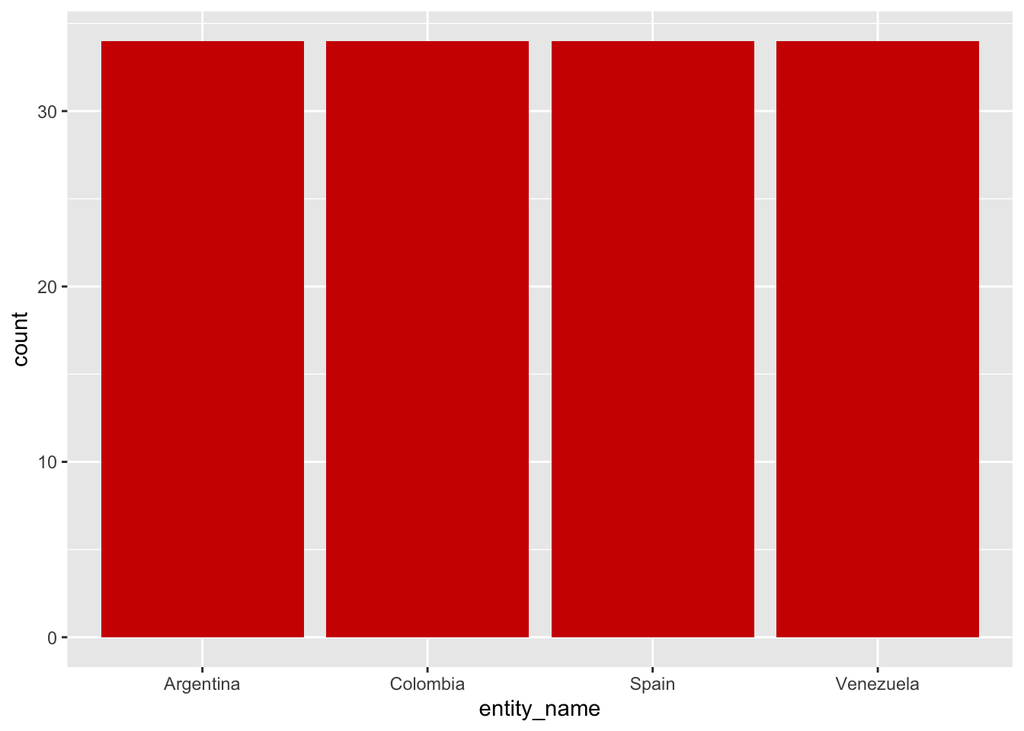

En este gráfico podemos observar que existe el mismo número de observaciones para cada país

## Gráfico de Bigotes

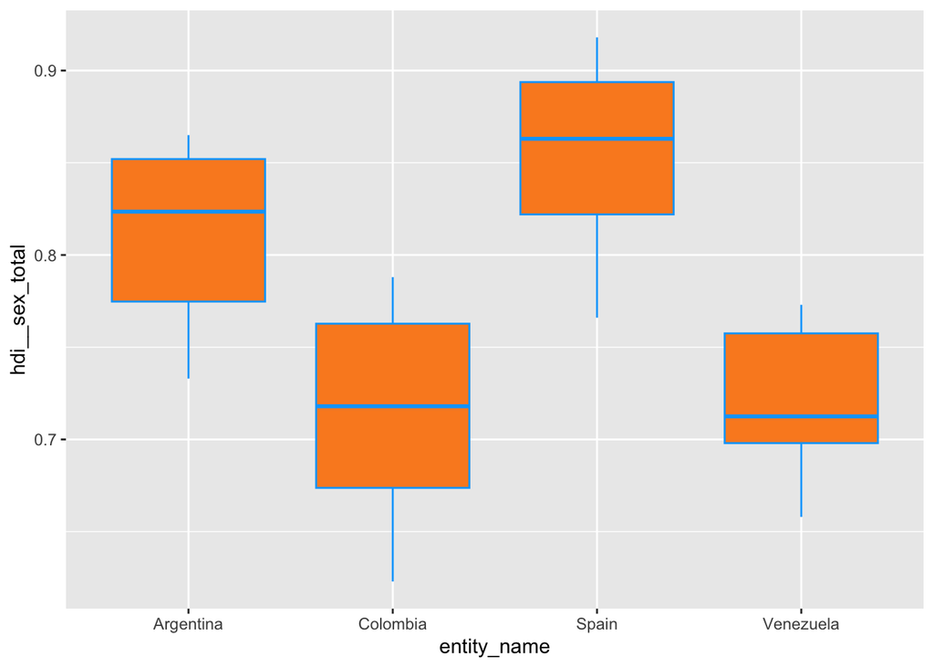

## Histograma

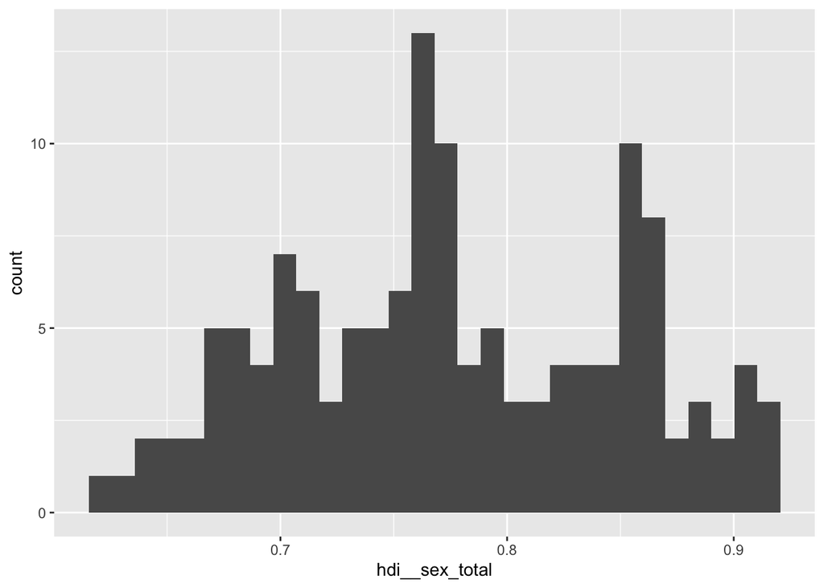

## Histograma por País

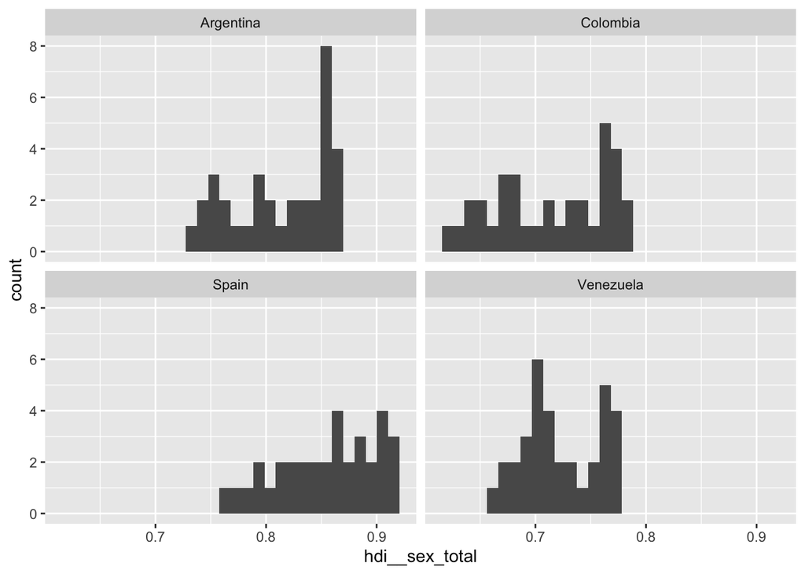

Al añadir `+` `facet_wrap(~entity_name)` en la función nos permite ver el historgrama de cada país siendo esto de mucha utilidad porque podemos visualizar el comportamiento y la forma de distribución de los datos de cada país.

Aquí podemos observar que tanto España, Argentina y Colombia tienen distribuciones de cola izquierda y que en el caso de Venezuela vemos una distribución mas irregular pero con una forma leptocurtica. Tambien podemos ver los datos de IDH con mayores observaciones por país, en Argentina es aproximadamente 0.86, en Colombia es aproximandamente 0.77, en España es aproximadamente 0.87 / 0.91 y en Venezuela es aproximadamente 0.7

## Gráfico de Densidad

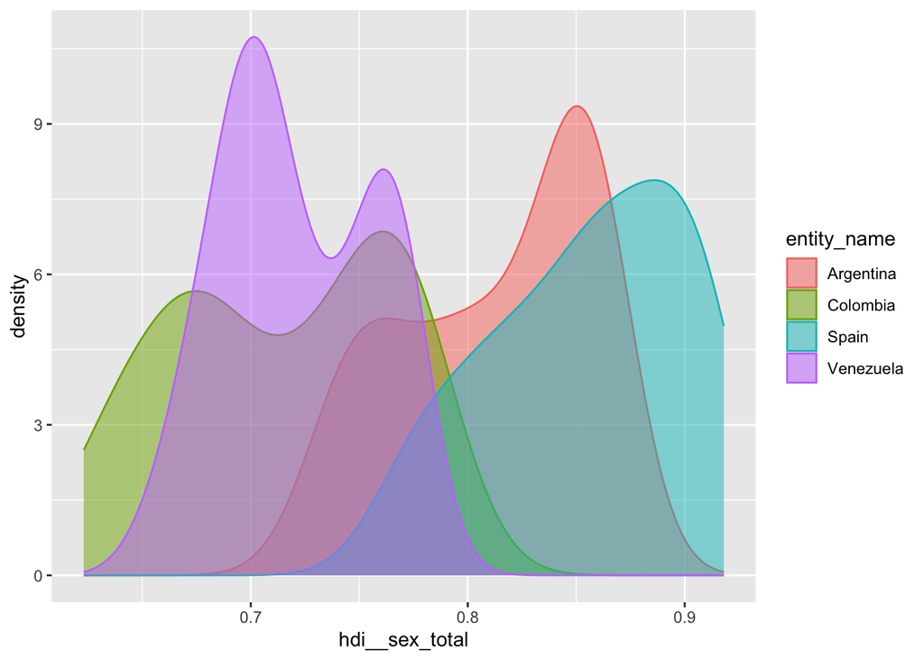

Con este gráfico podemos observar que la distribución de los datos de cada país expresados de forma continua nos arroja que todas a excepción de España poseen una distribución irregular con 2 picos.

## Gráfico de Lineas

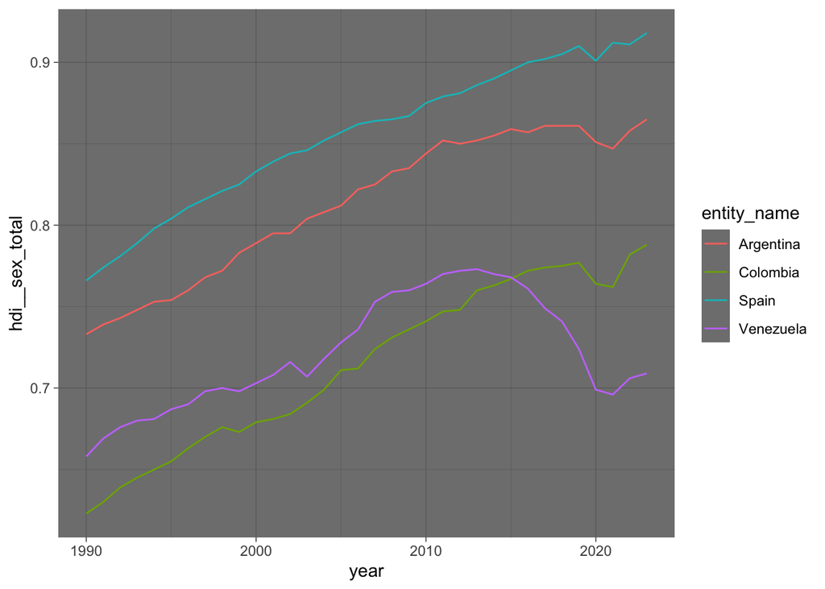

Con este grafico de lineas podemos visualizar la evolución del IDH a lo largo del tiempo en cada uno de los paises seleccionados, donde en el caso de España, Argentina y Colombia podemos ver una tendencia hacia el crecimiento de esta variable donde para los años cercanos al 2020 experimento una disminución significativa que puede ser explicada por el Covid 19.

En el caso puntual de Venezuela podemos visualizar que la caída del IDH ocurre a partir de aproximadamente 2015 y empieza a recomponerse a partir de 2022 este comportamiento se ve explicado por la gran crisis economica, social y política que vive venezuela desde esos años, marcadas por la hiperinflación, la perdida de aproximadamente el 70% del PIB y el colapso de los servicios públicos básicos.

## Tabla GT

Índice de Desarrollo Humano (IDH)

| País | Año | IDH |
| --- | --- | --- |
| Argentina | 2023 | 0.865 |
| Colombia | 2023 | 0.788 |
| Spain | 2023 | 0.918 |
| Venezuela | 2013 | 0.773 |